# "E-Mail Sending Time" Challenge Solution

**Author: Luis Moreira-Matias (luis.moreira.matias in Gmail)**

**Date: 10/09/2020**

The proposed solution is delivered under two chapters: I) Exploratory Data Analysis and II) Modelling.

## Executive Summary

- **Input data**: 100k customers with 3 features (X1,X2: continuous, X3:categorical). Each customer was sent 1-15 e-mails. The sent/reading e-mail times are also given.
- **Challenge**: Build a model that is able to predict the possible the best e-mail sending time to each customer, minimizing the elapsed time to its reading time.
- **EDA**: X1, X2 and X3 seem to be fairly independent among themselves;
- **EDA**: For 20% of the e-mails sent, the customers seem to respond immediately (<45m);
- **EDA**: Input data seems to be synthetically generated;
- **EDA**: Customers read most of the e-mails in the evening and morning peaks (around 20h and 09h), respectively. The e-mail readings almost do not happen during nighttime (00h-07h).
- **EDA**: The number of e-mails sent to each customer as well as the sending times seem to be drawn at random;
- **EDA**: X1 and X3 have a nearly linear dependence on predicting if a customer is a fast responder or not;
- **EDA**: X2 has a dependence on the observed time;
- **Modelling**: Major modelling problem is the assymetric nature of our optimization metric as, if we predict a sending time that occurs after the optimal reading time, we need to assume that the e-mail will only be read on the next day (i.e. a prediction error of -60m is actually an error of 23h!);
- **Solution**: GBM (w/ lightGBM package) + a customized loss function (assymetric). It uses two features: 1) X2 and a 2) linear combination of X1 and X3.
- **Result**: Average reading time of 2h (120m). In test set, 50% of e-mails sent are read within 1h while 75% are read within 2h.

## Reproducibility Issues

- If there is interest to recompile the code/notebooks, it is necessary to the manual assign of an absolute path inside of the code - that can be found right after library imports.
- Ideally, the code would only reproduce perfectly inside of a VM/docker. In the absence of that, I report on the major versions and packages used to create this.:
  - Ubuntu 18.04
  - Python 3.6.9
  - Numpy 1.18.2
  - Pandas 1.0.3
  - matplotlib 3.2.1
  - Seaborn 0.10
  - Sklearn 0.22.2.post1
  - lightgbm 3.0.0
  - jupyter core: 4.6.3
  - jupyter-notebook: 6.0.3

## I) EDA - Objectives and Tasks

- Understand the data, exploring it and draw patterns
- Training/Test Data Slicing
- Remove Erroneous Data Points and/or impute/handle missing data
- Formulate the problem as a ML one
- Design labels

```python
#loading dependences
import numpy as np
import pandas as pd
import matplotlib.pyplot as plt
import seaborn as sns
import random
import math

from grepfunc import grep
from sklearn.preprocessing import StandardScaler
from sklearn.ensemble import RandomForestRegressor
from sklearn.ensemble import RandomForestClassifier
import lightgbm
from sklearn.linear_model import LogisticRegression
from sklearn.metrics import roc_auc_score

#reproducible seeds
seed_constant = 33
np.random.seed(seed_constant)
random.seed(seed_constant)

#my path
path = '/home/luismoreira/Desktop/email_sending_time_challenge/'

#reading clientdata
data = pd.read_csv(path + "orig.data/data.csv")
data.info()
data.head()
```

```
<class 'pandas.core.frame.DataFrame'>
RangeIndex: 100000 entries, 0 to 99999
Data columns (total 34 columns):
 #   Column  Non-Null Count   Dtype
---  ------  --------------   -----
 0   X1      100000 non-null  float64
 1   X2      100000 non-null  float64
 2   X3      100000 non-null  int64
 3   M       100000 non-null  int64
 4   TS00    100000 non-null  object
 5   TO00    100000 non-null  object
 6   TS01    93229 non-null   object
 7   TO01    93229 non-null   object
 8   TS02    86468 non-null   object
 9   TO02    86468 non-null   object
```

[output cut: 26 more lines]

|  | X1 | X2 | X3 | M | TS00 | TO00 | TS01 | TO01 | TS02 | TO02 | ... | TS10 | TO10 | TS11 | TO11 | TS12 | TO12 | TS13 | TO13 | TS14 | TO14 |
| --- | --- | --- | --- | --- | --- | --- | --- | --- | --- | --- | --- | --- | --- | --- | --- | --- | --- | --- | --- | --- | --- |
| 0 | -1.25 | -0.88 | 2 | 14 | 14:00 | 22:27 | 18:00 | 14:37 | 13:00 | 09:39 | ... | 10:00 | 21:29 | 10:00 | 08:47 | 15:00 | 10:06 | 10:00 | 09:14 | NaN | NaN |
| 1 | -0.14 | -3.21 | 0 | 1 | 17:00 | 17:11 | NaN | NaN | NaN | NaN | ... | NaN | NaN | NaN | NaN | NaN | NaN | NaN | NaN | NaN | NaN |
| 2 | 1.23 | 0.08 | 3 | 1 | 19:00 | 09:22 | NaN | NaN | NaN | NaN | ... | NaN | NaN | NaN | NaN | NaN | NaN | NaN | NaN | NaN | NaN |
| 3 | -0.38 | -1.30 | 3 | 2 | 12:00 | 12:38 | 08:00 | 09:04 | NaN | NaN | ... | NaN | NaN | NaN | NaN | NaN | NaN | NaN | NaN | NaN | NaN |
| 4 | -1.50 | 0.22 | 2 | 6 | 14:00 | 21:59 | 11:00 | 17:01 | 15:00 | 23:47 | ... | NaN | NaN | NaN | NaN | NaN | NaN | NaN | NaN | NaN | NaN |

5 rows × 34 columns

### 1.1 Unsupervised EDA

Let's separate client features from e-mail activity/labels, adding a primary key beforehand. Let's also rename the features with prefixes for easier identification.

```python
clientdata = data.filter(['X1','X2','X3']).copy()
clientdata = clientdata.add_prefix('client_')
emaildata = data.drop(columns = ['X1','X2','X3']).copy()
emaildata = emaildata.add_prefix('email_')

clientdata['clientID'] = np.arange(0,len(clientdata)) + 1
emaildata['clientID'] = np.arange(0,len(emaildata)) + 1
data = clientdata.merge(emaildata, on = 'clientID').copy().reset_index()

#sanity check...
data.head()
data.columns
```

```
Index(['index', 'client_X1', 'client_X2', 'client_X3', 'clientID', 'email_M',
       'email_TS00', 'email_TO00', 'email_TS01', 'email_TO01', 'email_TS02',
       'email_TO02', 'email_TS03', 'email_TO03', 'email_TS04', 'email_TO04',
       'email_TS05', 'email_TO05', 'email_TS06', 'email_TO06', 'email_TS07',
       'email_TO07', 'email_TS08', 'email_TO08', 'email_TS09', 'email_TO09',
       'email_TS10', 'email_TO10', 'email_TS11', 'email_TO11', 'email_TS12',
       'email_TO12', 'email_TS13', 'email_TO13', 'email_TS14', 'email_TO14'],
      dtype='object')
```

Let's focus on clientdata for the timebeing. We know we have 3 features...X1,X2 are numerical while X3 is said to be categorical. Let's try to understand if we have missing values in any of the features.

```python
NA_cols = clientdata.columns[clientdata.isna().any()]
print(len(NA_cols))
```

```
0
```

- No missing values. Let's now look to the univariate distributions of each feature.

```
array([[<matplotlib.axes._subplots.AxesSubplot object at 0x7f02d515a710>,
      dtype=object)
```

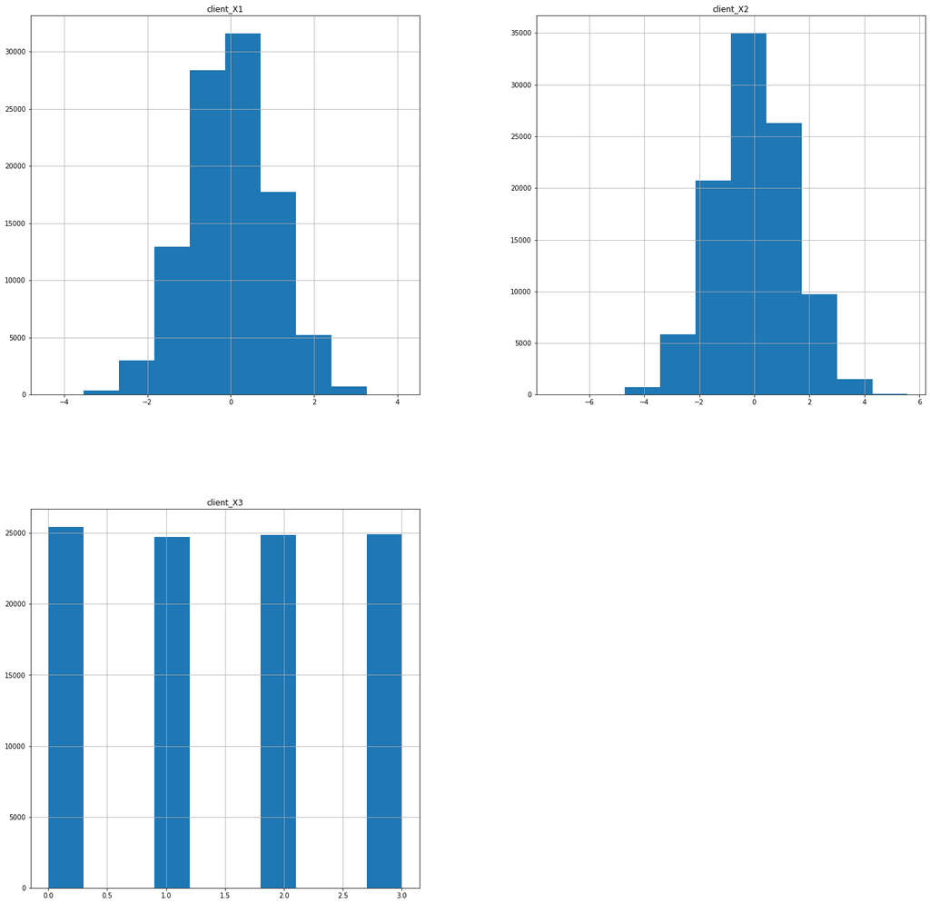

```python
clientdata.drop(columns =['clientID']).hist(figsize=(24,24))
```

- X1 and X2 have a somewhat gaussian distribution while X3 follows an uniform one.
- The levels of X3 are ordinal...however, we do not know if that order actually exists.

For the sake of time, We will take the information given by the assessment as ground truth and ignore any ordinality that may exist in X3. Let's try to understand how they relate with each other.

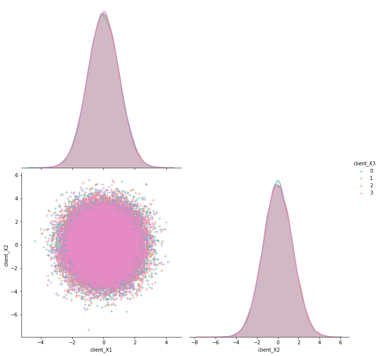

```python
g = sns.pairplot(clientdata.drop(columns =['clientID']), hue="client_X3", palette="Set2", diag_kind="kde", height=5, corner=True, markers="+", diag_kws=dict(shade=True))
```

- X1 and X2 seem to be fairly independent of X3 as their distributions among the different classes are very similar
- However, p(X1,X2|X3) seems to change for different X3 levels - in specific, it is plausible that the variance of p(X1,X2) is slightly larger for X3=0 than when X3=3.

There is not much that can be concluded from these analysis that could be taken as an actionable insight.

### 1.2 Supervised EDA

Let's separate train and test to avoid data leakage about the labels.

```python
#shuffle order to avoid input biases
data = data.reindex(np.random.permutation(data.index)).copy()
data.reset_index(drop = True, inplace = True)
data.head()

#randomly sampling 70% of the data for training and 30% for testing

#70% for training
training_data = data.sample(n=math.floor(0.7 * len(data.index)), random_state = seed_constant).copy()
training_data.reset_index(drop = True, inplace = True)
training_data.drop(columns = 'index', inplace = True)

training_IDs = pd.Series(training_data.clientID)
idx_test = np.where(np.logical_not(data.clientID.isin(training_data.clientID)))[0]
idx_test = data.index[idx_test]

#30% for testing
test_data = data.iloc[idx_test,:].copy()
test_data.reset_index(drop = True, inplace = True)
test_data.drop(columns = 'index', inplace = True)

#sanity check
print(training_data.shape)
print(test_data.shape)
training_data.head()
test_data.head()
print(training_data.clientID.isin(test_data.clientID).to_numpy().any())
#done!!
```

```
(70000, 35)
(30000, 35)
False
```

Let's start by observing the distribution of e-mails sent to each customer.

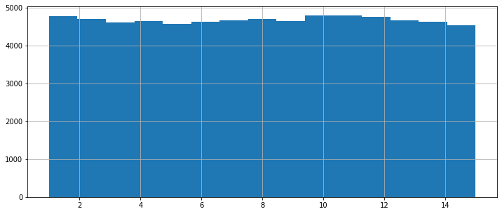

```python
training_data.email_M.hist(bins = 15, figsize=(12,5))
```

- It seems to be uniform. will it be related to the typical e-mail obser. time of each customer?

In order to answer that question, analyze e-mail sent observed data better and its potential relationship with clientdata features, we would need to "melt" the dataset, transforming each row into a record of an e-mail/sent and observed.

```python
#melting dataset
feats_to_melt = grep(training_data.columns, "email_TS", i=False, v=False)
training_data_melted_ts = pd.melt(training_data, id_vars = 'clientID', value_vars = feats_to_melt)

feats_to_melt = grep(training_data.columns, "email_TO", i=False, v=False)
training_data_melted_to = pd.melt(training_data, id_vars = 'clientID', value_vars = feats_to_melt)

feats_to_keep = grep(training_data.columns, "email_T", i=False, v=True)
training_data_melted = training_data_melted_ts.merge(training_data.filter(feats_to_keep), how="left", left_on="clientID", right_on = 'clientID').copy().reset_index()
training_data_melted = training_data_melted.merge(training_data_melted_to, on="clientID").copy().reset_index()
training_data_melted.drop(columns = ['level_0','index'], inplace = True)

#filtering only correct and relevant lines/combinations
sel_cases_idx = np.where(training_data_melted.variable_x.str.slice(start = 8, stop = 10) == training_data_melted.variable_y.str.slice(start = 8, stop = 10))[0]
sel_cases_idx = training_data_melted.index[sel_cases_idx]

training_data_melted = training_data_melted.iloc[sel_cases_idx,:].copy()
training_data_melted.reset_index(drop = True, inplace = True)

sel_cases_idx = np.where(np.logical_not(training_data_melted.isnull().any(axis=1)))[0]
sel_cases_idx = training_data_melted.index[sel_cases_idx]

training_data_melted = training_data_melted.iloc[sel_cases_idx,:].copy()
training_data_melted.reset_index(drop = True, inplace = True)


#sanity check
print(training_data_melted.shape)
training_data_melted.head(50)
#done
```

```
(559565, 9)
```

|  | clientID | variable_x | value_x | client_X1 | client_X2 | client_X3 | email_M | variable_y | value_y |
| --- | --- | --- | --- | --- | --- | --- | --- | --- | --- |
| 0 | 53264 | email_TS00 | 15:00 | -2.10 | 0.09 | 3 | 14 | email_TO00 | 15:34 |
| 1 | 53264 | email_TS01 | 10:00 | -2.10 | 0.09 | 3 | 14 | email_TO01 | 10:22 |
| 2 | 53264 | email_TS02 | 12:00 | -2.10 | 0.09 | 3 | 14 | email_TO02 | 12:50 |
| 3 | 53264 | email_TS03 | 11:00 | -2.10 | 0.09 | 3 | 14 | email_TO03 | 11:07 |
| 4 | 53264 | email_TS04 | 19:00 | -2.10 | 0.09 | 3 | 14 | email_TO04 | 21:51 |
| 5 | 53264 | email_TS05 | 07:00 | -2.10 | 0.09 | 3 | 14 | email_TO05 | 07:14 |
| 6 | 53264 | email_TS06 | 11:00 | -2.10 | 0.09 | 3 | 14 | email_TO06 | 11:37 |
| 7 | 53264 | email_TS07 | 15:00 | -2.10 | 0.09 | 3 | 14 | email_TO07 | 16:02 |
| 8 | 53264 | email_TS08 | 20:00 | -2.10 | 0.09 | 3 | 14 | email_TO08 | 21:19 |
| 9 | 53264 | email_TS09 | 15:00 | -2.10 | 0.09 | 3 | 14 | email_TO09 | 16:07 |
| 10 | 53264 | email_TS10 | 14:00 | -2.10 | 0.09 | 3 | 14 | email_TO10 | 14:34 |
| 11 | 53264 | email_TS11 | 12:00 | -2.10 | 0.09 | 3 | 14 | email_TO11 | 12:25 |
| 12 | 53264 | email_TS12 | 15:00 | -2.10 | 0.09 | 3 | 14 | email_TO12 | 15:11 |
| 13 | 53264 | email_TS13 | 09:00 | -2.10 | 0.09 | 3 | 14 | email_TO13 | 09:02 |
| 14 | 6513 | email_TS00 | 15:00 | 1.50 | -2.19 | 0 | 3 | email_TO00 | 23:41 |
| 15 | 6513 | email_TS01 | 11:00 | 1.50 | -2.19 | 0 | 3 | email_TO01 | 20:43 |
| 16 | 6513 | email_TS02 | 20:00 | 1.50 | -2.19 | 0 | 3 | email_TO02 | 00:00 |
| 17 | 24354 | email_TS00 | 20:00 | 0.62 | -1.01 | 0 | 4 | email_TO00 | 14:14 |
| 18 | 24354 | email_TS01 | 17:00 | 0.62 | -1.01 | 0 | 4 | email_TO01 | 14:46 |
| 19 | 24354 | email_TS02 | 08:00 | 0.62 | -1.01 | 0 | 4 | email_TO02 | 17:11 |
| 20 | 24354 | email_TS03 | 12:00 | 0.62 | -1.01 | 0 | 4 | email_TO03 | 11:54 |
| 21 | 97840 | email_TS00 | 12:00 | -0.18 | -1.37 | 2 | 6 | email_TO00 | 09:36 |
| 22 | 97840 | email_TS01 | 16:00 | -0.18 | -1.37 | 2 | 6 | email_TO01 | 23:06 |
| 23 | 97840 | email_TS02 | 20:00 | -0.18 | -1.37 | 2 | 6 | email_TO02 | 19:44 |
| 24 | 97840 | email_TS03 | 07:00 | -0.18 | -1.37 | 2 | 6 | email_TO03 | 20:15 |
| 25 | 97840 | email_TS04 | 14:00 | -0.18 | -1.37 | 2 | 6 | email_TO04 | 20:30 |
| 26 | 97840 | email_TS05 | 20:00 | -0.18 | -1.37 | 2 | 6 | email_TO05 | 08:37 |
| 27 | 74494 | email_TS00 | 14:00 | -0.09 | 1.94 | 3 | 12 | email_TO00 | 14:53 |
| 28 | 74494 | email_TS01 | 14:00 | -0.09 | 1.94 | 3 | 12 | email_TO01 | 20:43 |
| 29 | 74494 | email_TS02 | 13:00 | -0.09 | 1.94 | 3 | 12 | email_TO02 | 14:50 |
| 30 | 74494 | email_TS03 | 12:00 | -0.09 | 1.94 | 3 | 12 | email_TO03 | 12:10 |
| 31 | 74494 | email_TS04 | 19:00 | -0.09 | 1.94 | 3 | 12 | email_TO04 | 19:11 |
| 32 | 74494 | email_TS05 | 07:00 | -0.09 | 1.94 | 3 | 12 | email_TO05 | 07:41 |
| 33 | 74494 | email_TS06 | 15:00 | -0.09 | 1.94 | 3 | 12 | email_TO06 | 15:23 |
| 34 | 74494 | email_TS07 | 17:00 | -0.09 | 1.94 | 3 | 12 | email_TO07 | 17:16 |
| 35 | 74494 | email_TS08 | 14:00 | -0.09 | 1.94 | 3 | 12 | email_TO08 | 14:26 |
| 36 | 74494 | email_TS09 | 07:00 | -0.09 | 1.94 | 3 | 12 | email_TO09 | 07:00 |
| 37 | 74494 | email_TS10 | 08:00 | -0.09 | 1.94 | 3 | 12 | email_TO10 | 08:10 |
| 38 | 74494 | email_TS11 | 11:00 | -0.09 | 1.94 | 3 | 12 | email_TO11 | 11:13 |
| 39 | 61795 | email_TS00 | 10:00 | -1.60 | 0.08 | 3 | 8 | email_TO00 | 10:58 |
| 40 | 61795 | email_TS01 | 07:00 | -1.60 | 0.08 | 3 | 8 | email_TO01 | 09:09 |
| 41 | 61795 | email_TS02 | 08:00 | -1.60 | 0.08 | 3 | 8 | email_TO02 | 11:07 |
| 42 | 61795 | email_TS03 | 10:00 | -1.60 | 0.08 | 3 | 8 | email_TO03 | 07:54 |
| 43 | 61795 | email_TS04 | 17:00 | -1.60 | 0.08 | 3 | 8 | email_TO04 | 17:20 |
| 44 | 61795 | email_TS05 | 20:00 | -1.60 | 0.08 | 3 | 8 | email_TO05 | 20:18 |
| 45 | 61795 | email_TS06 | 07:00 | -1.60 | 0.08 | 3 | 8 | email_TO06 | 07:13 |
| 46 | 61795 | email_TS07 | 18:00 | -1.60 | 0.08 | 3 | 8 | email_TO07 | 20:22 |
| 47 | 5859 | email_TS00 | 09:00 | 0.93 | -2.37 | 1 | 12 | email_TO00 | 21:10 |
| 48 | 5859 | email_TS01 | 17:00 | 0.93 | -2.37 | 1 | 12 | email_TO01 | 18:17 |
| 49 | 5859 | email_TS02 | 12:00 | 0.93 | -2.37 | 1 | 12 | email_TO02 | 16:47 |

Now, we need to transform these sending/observed times into greatnesses that we can work with.

To do it so, we will create three new processed variables:

- 1) response time (sent-obs in min.)
- 2) e-mail observed time-of-the-day (minutes)
- 3) e-mail observed time-of-the-day discrete (hours)

```python
#minutes sent
hours = training_data_melted.value_x.str.slice(start = 0, stop = 2).to_numpy()
minutes = training_data_melted.value_x.str.slice(start = 3, stop = 5).to_numpy()
training_data_melted['email_senttime'] = hours.astype(int) * 60 + minutes.astype(int)

#minutes observed
hours = training_data_melted.value_y.str.slice(start = 0, stop = 2).to_numpy()
minutes = training_data_melted.value_y.str.slice(start = 3, stop = 5).to_numpy()
training_data_melted['email_proc_obstime'] = hours.astype(int) * 60 + minutes.astype(int)

#hours observed
training_data_melted['email_proc_obshour'] = hours.astype(int)

#response_time
training_data_melted['email_proc_restime'] = training_data_melted['email_proc_obstime'] - training_data_melted['email_senttime']
sel_cases_idx = np.where(training_data_melted['email_proc_restime'] < 0)[0]
sel_cases_idx = training_data_melted.index[sel_cases_idx]
training_data_melted.loc[sel_cases_idx,'email_proc_restime'] = training_data_melted.loc[sel_cases_idx,'email_proc_restime'] + (24*60)


#dropping original melted columns
training_data_melted = training_data_melted.drop(columns = ['variable_x','value_x', 'variable_y', 'value_y'])

#sanity check
training_data_melted.head(50)

#done
```

|  | clientID | client_X1 | client_X2 | client_X3 | email_M | email_senttime | email_proc_obstime | email_proc_obshour | email_proc_restime |
| --- | --- | --- | --- | --- | --- | --- | --- | --- | --- |
| 0 | 53264 | -2.10 | 0.09 | 3 | 14 | 900 | 934 | 15 | 34 |
| 1 | 53264 | -2.10 | 0.09 | 3 | 14 | 600 | 622 | 10 | 22 |
| 2 | 53264 | -2.10 | 0.09 | 3 | 14 | 720 | 770 | 12 | 50 |
| 3 | 53264 | -2.10 | 0.09 | 3 | 14 | 660 | 667 | 11 | 7 |
| 4 | 53264 | -2.10 | 0.09 | 3 | 14 | 1140 | 1311 | 21 | 171 |
| 5 | 53264 | -2.10 | 0.09 | 3 | 14 | 420 | 434 | 7 | 14 |
| 6 | 53264 | -2.10 | 0.09 | 3 | 14 | 660 | 697 | 11 | 37 |
| 7 | 53264 | -2.10 | 0.09 | 3 | 14 | 900 | 962 | 16 | 62 |
| 8 | 53264 | -2.10 | 0.09 | 3 | 14 | 1200 | 1279 | 21 | 79 |
| 9 | 53264 | -2.10 | 0.09 | 3 | 14 | 900 | 967 | 16 | 67 |
| 10 | 53264 | -2.10 | 0.09 | 3 | 14 | 840 | 874 | 14 | 34 |
| 11 | 53264 | -2.10 | 0.09 | 3 | 14 | 720 | 745 | 12 | 25 |
| 12 | 53264 | -2.10 | 0.09 | 3 | 14 | 900 | 911 | 15 | 11 |
| 13 | 53264 | -2.10 | 0.09 | 3 | 14 | 540 | 542 | 9 | 2 |
| 14 | 6513 | 1.50 | -2.19 | 0 | 3 | 900 | 1421 | 23 | 521 |
| 15 | 6513 | 1.50 | -2.19 | 0 | 3 | 660 | 1243 | 20 | 583 |
| 16 | 6513 | 1.50 | -2.19 | 0 | 3 | 1200 | 0 | 0 | 240 |
| 17 | 24354 | 0.62 | -1.01 | 0 | 4 | 1200 | 854 | 14 | 1094 |
| 18 | 24354 | 0.62 | -1.01 | 0 | 4 | 1020 | 886 | 14 | 1306 |
| 19 | 24354 | 0.62 | -1.01 | 0 | 4 | 480 | 1031 | 17 | 551 |
| 20 | 24354 | 0.62 | -1.01 | 0 | 4 | 720 | 714 | 11 | 1434 |
| 21 | 97840 | -0.18 | -1.37 | 2 | 6 | 720 | 576 | 9 | 1296 |
| 22 | 97840 | -0.18 | -1.37 | 2 | 6 | 960 | 1386 | 23 | 426 |
| 23 | 97840 | -0.18 | -1.37 | 2 | 6 | 1200 | 1184 | 19 | 1424 |
| 24 | 97840 | -0.18 | -1.37 | 2 | 6 | 420 | 1215 | 20 | 795 |
| 25 | 97840 | -0.18 | -1.37 | 2 | 6 | 840 | 1230 | 20 | 390 |
| 26 | 97840 | -0.18 | -1.37 | 2 | 6 | 1200 | 517 | 8 | 757 |
| 27 | 74494 | -0.09 | 1.94 | 3 | 12 | 840 | 893 | 14 | 53 |
| 28 | 74494 | -0.09 | 1.94 | 3 | 12 | 840 | 1243 | 20 | 403 |
| 29 | 74494 | -0.09 | 1.94 | 3 | 12 | 780 | 890 | 14 | 110 |
| 30 | 74494 | -0.09 | 1.94 | 3 | 12 | 720 | 730 | 12 | 10 |
| 31 | 74494 | -0.09 | 1.94 | 3 | 12 | 1140 | 1151 | 19 | 11 |
| 32 | 74494 | -0.09 | 1.94 | 3 | 12 | 420 | 461 | 7 | 41 |
| 33 | 74494 | -0.09 | 1.94 | 3 | 12 | 900 | 923 | 15 | 23 |
| 34 | 74494 | -0.09 | 1.94 | 3 | 12 | 1020 | 1036 | 17 | 16 |
| 35 | 74494 | -0.09 | 1.94 | 3 | 12 | 840 | 866 | 14 | 26 |
| 36 | 74494 | -0.09 | 1.94 | 3 | 12 | 420 | 420 | 7 | 0 |
| 37 | 74494 | -0.09 | 1.94 | 3 | 12 | 480 | 490 | 8 | 10 |
| 38 | 74494 | -0.09 | 1.94 | 3 | 12 | 660 | 673 | 11 | 13 |
| 39 | 61795 | -1.60 | 0.08 | 3 | 8 | 600 | 658 | 10 | 58 |
| 40 | 61795 | -1.60 | 0.08 | 3 | 8 | 420 | 549 | 9 | 129 |
| 41 | 61795 | -1.60 | 0.08 | 3 | 8 | 480 | 667 | 11 | 187 |
| 42 | 61795 | -1.60 | 0.08 | 3 | 8 | 600 | 474 | 7 | 1314 |
| 43 | 61795 | -1.60 | 0.08 | 3 | 8 | 1020 | 1040 | 17 | 20 |
| 44 | 61795 | -1.60 | 0.08 | 3 | 8 | 1200 | 1218 | 20 | 18 |
| 45 | 61795 | -1.60 | 0.08 | 3 | 8 | 420 | 433 | 7 | 13 |
| 46 | 61795 | -1.60 | 0.08 | 3 | 8 | 1080 | 1222 | 20 | 142 |
| 47 | 5859 | 0.93 | -2.37 | 1 | 12 | 540 | 1270 | 21 | 730 |
| 48 | 5859 | 0.93 | -2.37 | 1 | 12 | 1020 | 1097 | 18 | 77 |
| 49 | 5859 | 0.93 | -2.37 | 1 | 12 | 720 | 1007 | 16 | 287 |

```python
print(training_data_melted.shape)
```

```
(559565, 9)
```

Let's quickly check if all proc. observed times are valid before proceeding

```python
df = training_data_melted['email_proc_obshour'].value_counts()
print(df)
```

```
 9     66537
 8     62560
 10    41998
 20    37543
 19    33026
 7     30205
 11    29459
 21    29344
 12    28598
 13    28424
 14    26632
 18    26605
 15    23964
 17    22533
 16    22119
 22    21373
 23    13028
 0      6104
 6      4811
 1      2334
 5      1015
 2       663
 4       372
 3       317
-1         1
Name: email_proc_obshour, dtype: int64
```

- There is a strange negative number...let's see if it also exists sometehing problematic on sent times...

```python
print(len(np.where((training_data_melted.email_senttime < 0) | (training_data_melted.email_senttime >= 24*60))[0]))
```

```
0
```

No...so, let's just remove the strange and isolated example from training before proceeding.

```python
sel_cases_idx = np.where(training_data_melted.email_proc_obshour >= 0)[0]
sel_cases_idx = training_data_melted.index[sel_cases_idx]

training_data_melted = training_data_melted.iloc[sel_cases_idx,:].copy()
training_data_melted.reset_index(drop = True, inplace = True)
```

Let's analyze the response time...

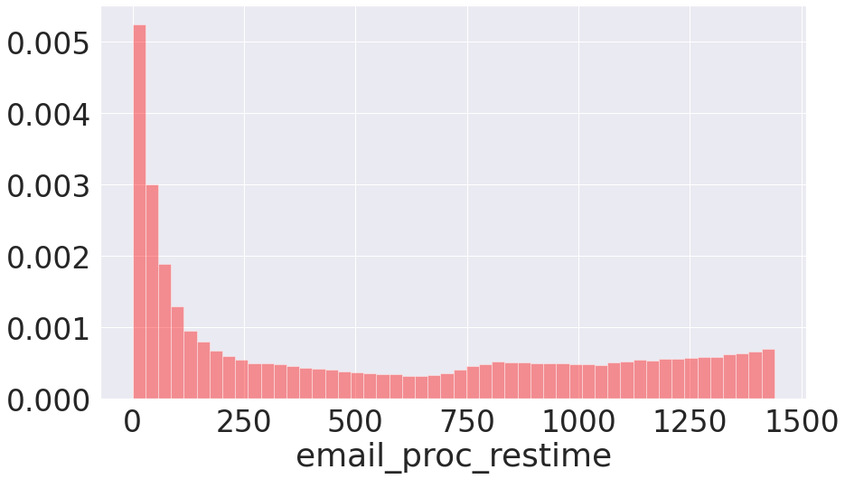

```python
plt.figure(figsize=(14,8))
sns.set(font_scale=3)
ab = sns.distplot(training_data_melted['email_proc_restime'], kde=False, color='red', norm_hist = True)
```

- We notice that, in ~20% of the emails sent, the customers respond fast whereas then an uniform pattern is followed. Let's use this value to define a 'fast response customer'.

```
43.0
```

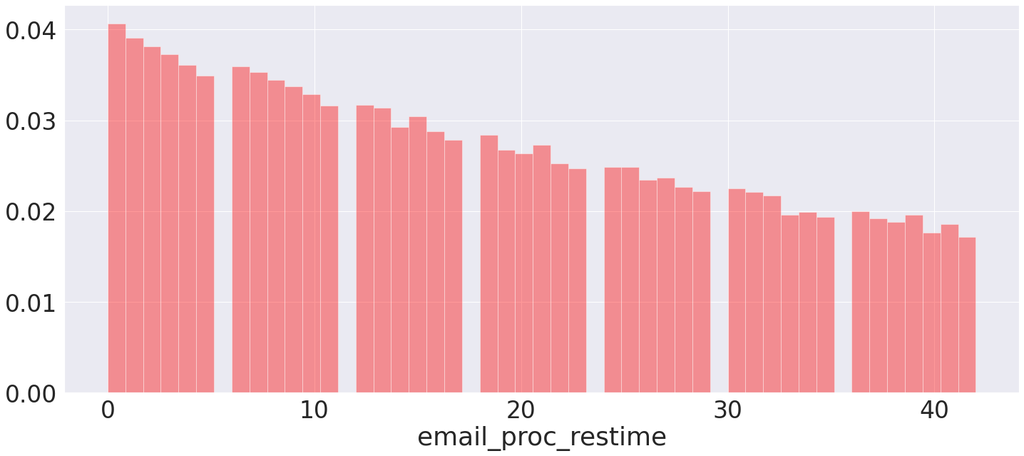

```python
min_th = training_data_melted['email_proc_restime'].quantile(0.20)
sel_cases_idx = np.where(training_data_melted['email_proc_restime'] < min_th)[0]
sel_cases_idx = training_data_melted.index[sel_cases_idx]

plt.figure(figsize=(24,10))
sns.set(font_scale=3)
ab = sns.distplot(training_data_melted.loc[sel_cases_idx,'email_proc_restime'], kde=False, color='red', norm_hist = True)
print(min_th)
```

- the distribution is actually quite uniformily descending without a particular spike within
- this turns the selected threshold (20% quantile, 43min. of response time) quite realistic to assume an immediate reading of the e-mail
- there is also a particularly funny effect: there are no response times equal to multiples of 7...as it is easily confirmable analytically

```python
print(ab.patches[7-1].get_height())
print(ab.patches[14-1].get_height())
print(ab.patches[14*3-1].get_height())
```

```
0.0
0.0
0.0
```

- This effect points out that this data is not real but synthetically generated instead. Let's now quickly analyze hour of the day (observed).

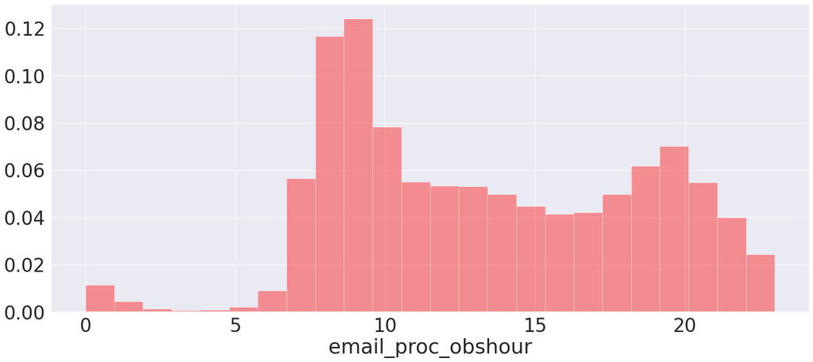

```python
plt.figure(figsize=(24,10))
sns.set(font_scale=3)
sns.distplot(training_data_melted['email_proc_obshour'], kde=False, color='red', bins = 24, norm_hist = True)
```

- Here, we notice that the customers barely read e-mails from 0 to 6am, showing two peaks around 09h and 20h (as observed before)
- We may also conclude that it is not worthy to send e-mails between 0-6am at all.

Let's see if exists any relationship between this variable and the number of e-mails sent to each customer... if that exists, we may generate some aggregation features of these numbers vs. clientdata.

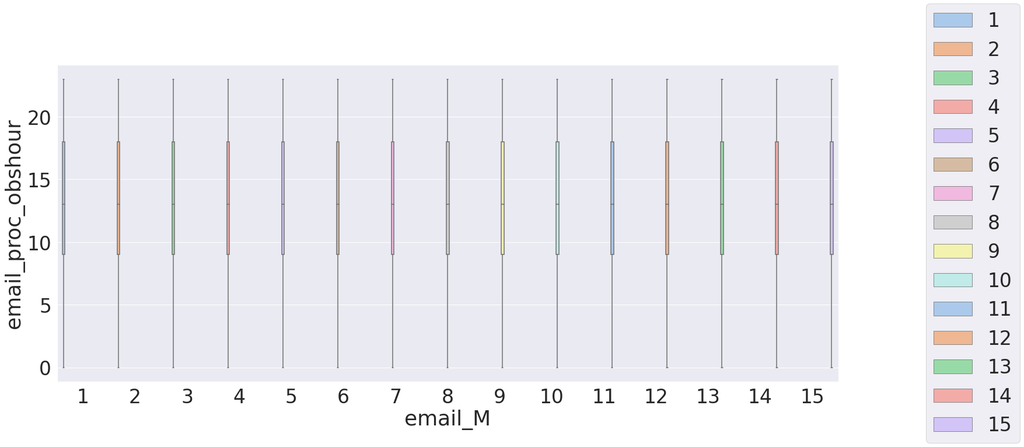

```python
data_viz = training_data_melted.filter(['email_proc_obshour', 'email_M'])
plt.figure(figsize=(24,10))
sns.set(font_scale=3)
g = sns.boxplot(data = data_viz, hue="email_M", palette="pastel",   x = 'email_M', y = 'email_proc_obshour')
g.legend(loc='center left', bbox_to_anchor=(1.1, 0.5), ncol=1)
```

- No...the number of e-mails sent to each customer seems to be independent from the typical e-mail observed time.

Let's discretize the reading time in three folds: 1: 07h-13h, 2: 13h-24h, 0: other time periods of the day.

The intuition to use these bins is the peaks/valleys observed in the figure + the hint on the assessment description about the customers observe the e-mail before/after lunch (defined here as 13h).

```python
training_data_melted['email_proc_obsblock'] = 0

#7h-13h
sel_idx = np.where((training_data_melted['email_proc_obshour'] >= 7) & (training_data_melted['email_proc_obshour'] < 13))[0]
sel_idx = training_data_melted.index[sel_idx]
training_data_melted.loc[sel_idx,'email_proc_obsblock'] = 1
print(len(sel_idx))

#13h-24h
sel_idx = np.where((training_data_melted['email_proc_obshour'] >= 13) & (training_data_melted['email_proc_obshour'] < 24))[0]
sel_idx = training_data_melted.index[sel_idx]
training_data_melted.loc[sel_idx,'email_proc_obsblock'] = 2
print(len(sel_idx))
```

```
259357
284591
```

Now that we have some new e-mail-related processed variables, let's use pairplots explore relationships between these new variables, the number of messages sent to each customer and clientdata.

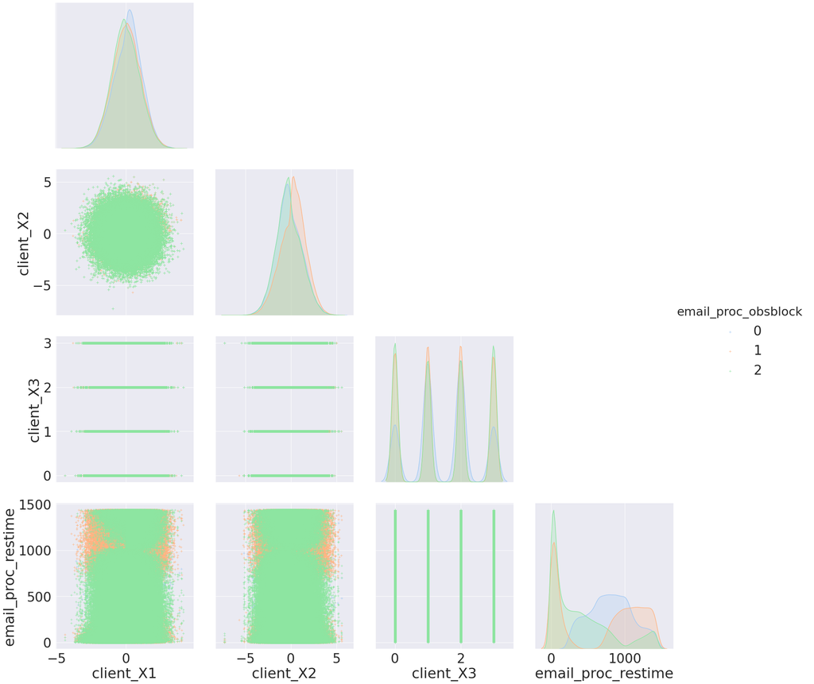

```python
data_viz = training_data_melted.filter(['email_proc_obsblock','client_X1','client_X2','client_X3', 'email_proc_restime'])
g = sns.pairplot(data_viz,  hue="email_proc_obsblock", palette="pastel",  height = 6, corner=True, markers="+")
```

- There are , at least, 2 conclusions to take out of this chart:
  - 1) X1, X2 and X3 seem to have influence over the observed e-mail time
  - 2) The response time seems invariably different across time blocks

Let's now look more closely on the response times...

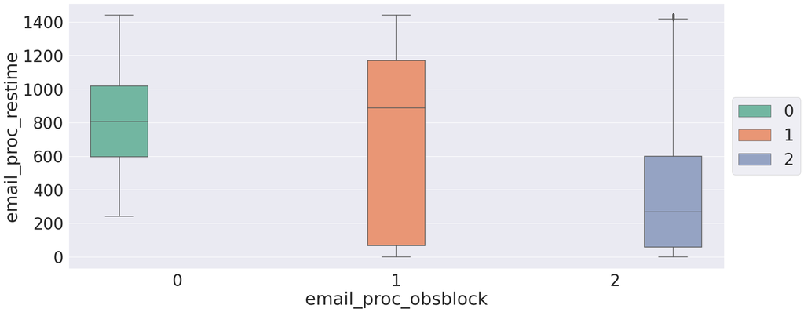

```python
data_viz = training_data_melted.filter(['email_proc_obsblock', 'email_proc_restime'])
plt.figure(figsize=(24,10))
sns.set(font_scale=3)
g = sns.boxplot(data = data_viz, hue="email_proc_obsblock", palette="Set2",   x = 'email_proc_obsblock', y = 'email_proc_restime')
g.legend(loc='center left', bbox_to_anchor=(1., 0.5), ncol=1)
plt.show()
```

- The e-mail opening time seem to be lower whenever it is received on time block 2
- This may be explained if the e-mail sent times suffer some bias (namely, if we are sending more e-mails at these periods than throughout the day)

Let's quickly assess that by looking to the distribution of sent times

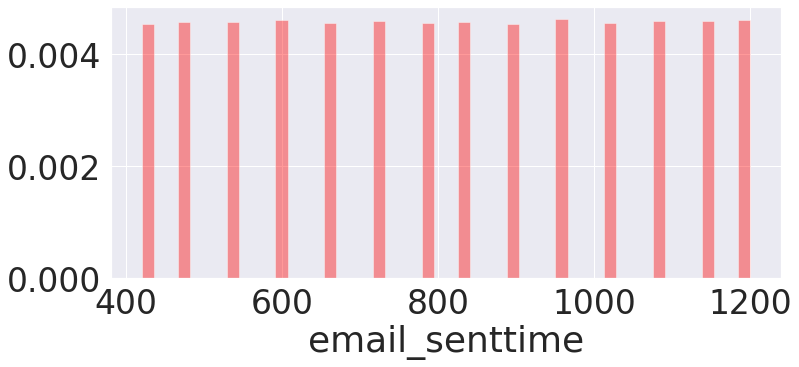

```python
plt.figure(figsize=(12,5))
sns.set(font_scale=3)
ab = sns.distplot(training_data_melted['email_senttime'], kde=False, color='red', norm_hist = True)
```

- Indeed, the distribution of email sending times is nearly uniform...consequently, whomever reads the e-mails after 14h-00h tends to read them faster
- Does this makes sense? not really...
- This observed "pattern" in the data can also be explained if people just reads the e-mails in certain periods of the day... pushing e-mails sent in other times to be read in the next day.
- This behavior will enlarge considerably the reading time

Let's try to observe that in the data by 1) excluding those 'next day' reading points and 2) redo the boxplots. If a pattern of "users that read their e-mails later in the day have shorter reading times", this must be observable in this procedure.

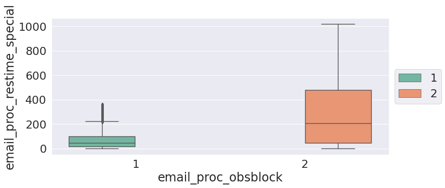

```python
#filtering 'only same day' cases
training_data_melted['email_proc_restime_special'] = training_data_melted['email_proc_obstime'] - training_data_melted['email_senttime']
sel_cases_idx = np.where(training_data_melted['email_proc_restime_special'] >= 0)[0]
sel_cases_idx = training_data_melted.index[sel_cases_idx]
data_viz = training_data_melted.iloc[sel_cases_idx,:].copy()
data_viz.reset_index(drop = True,  inplace = True)

#replotting the boxplots of response times
plt.figure(figsize=(12,5))
sns.set(font_scale=2)
g = sns.boxplot(data = data_viz, hue="email_proc_obsblock", palette="Set2",   x = 'email_proc_obsblock', y = 'email_proc_restime_special')
g.legend(loc='center left', bbox_to_anchor=(1., 0.5), ncol=1)
plt.show()
```

- In this chart, we depict that the reading times are actually longer in the afternoon than in the morning
- This makes sense as the block 13h-24h is way larger (50%) than the block 07h-13h and as we excluded "next day cases"
- This is also a good hint as there no trend on the response times whatsoever. Most likely, the e-mails are sent completely at random.

### 1.3 Label Construction

Now we need to formulate our ML problem as a supervised learning one, focusing on the e-mail opening times. For that, we will need to create labels.

There are two main options to model the problem: 1) regression or 2) classification

- 1) **regression** using a continuous target is an option. However, the default loss functions are symmetric...penalizing equalliy errors regardless of their signal. Moreover, there are some customers that simply answer immediately to their e-mails...adding noise to the modelling that needs to be done for others.
- #) classification with a discretized target - It would suffer the same problem than regression - common loss functions are symmetric. Therefore, in order to achieve good results, we would need to express a quantity on the loss as different types of errors will cost more than others.

To explore these options, we will create three labels:

- i) opening times (minutes), (continuous) - already there as "email_proc_obstime"
- ii) opening times (blocks). (discrete) - already there as "email_proc_obsblock"
- iii) respond immediately (binary) yes/no

In order to compute the latter, we have to define a pattern behavior as we consider to respond immediately. We will define it as follows:

- if a customer answered in 60 minutes (using the 43 minutes computed above as reference and giving some slack) to more than 50% of the sent e-mails in two different blocks of the day, he is considered to be an immediate responder. Otherwise, he is considered a seasonal one (only mornings/evenings)

Let's implement this!

```python
data_viz = training_data_melted.filter(['clientID','email_proc_restime','email_proc_obstime', 'email_proc_obsblock'])
min_th_fast_response = 60

#create number of favorable cases vs. number of observations
data_viz2 = data_viz.copy()
sel_cases_idx = np.where(data_viz2.email_proc_restime < min_th_fast_response)[0]
sel_cases_idx = data_viz2.index[sel_cases_idx]
data_viz2 = data_viz2.iloc[sel_cases_idx,:].copy()
data_viz2.reset_index(drop = True,  inplace = True)

fast_counts = data_viz2.groupby(['clientID']).size().to_frame()
fast_counts.reset_index(level=0, inplace=True)
fast_counts = fast_counts.rename(columns={0: "fast_counts"})

all_counts = data_viz.groupby(['clientID']).size().to_frame()
all_counts.reset_index(level=0, inplace=True)
all_counts = all_counts.rename(columns={0: "all_counts"})

fast_counts = fast_counts.merge(all_counts, how="left", left_on="clientID", right_on = 'clientID').copy().reset_index(drop = True)
fast_counts['perc_fast_counts'] = fast_counts.fast_counts / fast_counts.all_counts

#selecting customers with 4+ e-mails sent/received and with 50%+ of fast responses
sel_fast_cases_idx = np.where((fast_counts.perc_fast_counts >= 0.5) & (fast_counts.all_counts >= 4))[0]
fast_counts = fast_counts.iloc[sel_fast_cases_idx,:].copy()
fast_counts.reset_index(drop = True, inplace = True)


#merge to prune out invalid clientIDs with sanity check
print(fast_counts.shape)
fast_counts = fast_counts.merge(data_viz2, how="left", left_on="clientID", right_on = 'clientID').copy().reset_index(drop = True)
print(len(fast_counts.clientID.unique()))
#done
```

```
(13514, 4)
13514
```

```python
#removing all non-fast cases w/ sanity check
print(len(fast_counts.clientID.unique()))
sel_cases_idx = np.where(fast_counts.email_proc_restime < min_th_fast_response)[0]
sel_cases_idx = fast_counts.index[sel_cases_idx]
fast_counts = fast_counts.iloc[sel_cases_idx,:].copy()
fast_counts.reset_index(drop = True,  inplace = True)
print(len(fast_counts.clientID.unique()))
```

```
13514
13514
```

```python
#counting occurrences in different periods of the day
df = fast_counts.groupby('clientID')['email_proc_obsblock'].value_counts().unstack()
df = df.count(axis=1).to_frame()
df.reset_index(level=0, inplace=True)
df = df.rename(columns={0: "different_periods"})

#excluding cases which occur always in the same period of the day w/sanity check
print(df.shape)
sel_cases_idx = np.where(df.different_periods > 1)[0]
sel_cases_idx = df.index[sel_cases_idx]
df = df.iloc[sel_cases_idx,:].copy()
df.reset_index(drop = True,  inplace = True)
print(df.shape)
```

```
(13514, 2)
(12459, 2)
```

```python
#adding info to original training set, w/ sanity check
print(df.shape)
training_data_melted['email_proc_fast_responder'] = 0
sel_cases_idx = np.where(training_data_melted.clientID.isin(df.clientID))[0]
sel_cases_idx = training_data_melted.index[sel_cases_idx]
training_data_melted.loc[sel_cases_idx,'email_proc_fast_responder'] = 1
print(len(training_data_melted.clientID[sel_cases_idx].unique()))
#done
```

```
(12459, 2)
12459
```

Let's explore again clientdata with this new label...

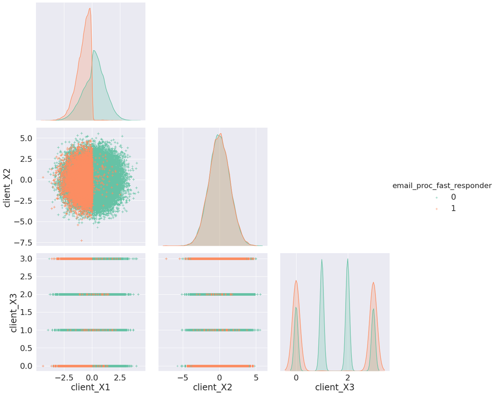

```python
data_viz = training_data_melted.filter(['email_proc_fast_responder','client_X1','client_X2','client_X3'])
g = sns.pairplot(data_viz, hue="email_proc_fast_responder", palette="Set2",  height=5, corner=True, markers="+")
```

- X1 and X3 have a very strong predictive power over this new label
- moreover, the relationship seems to be linear Let's keep this in mind for the modelling stage.

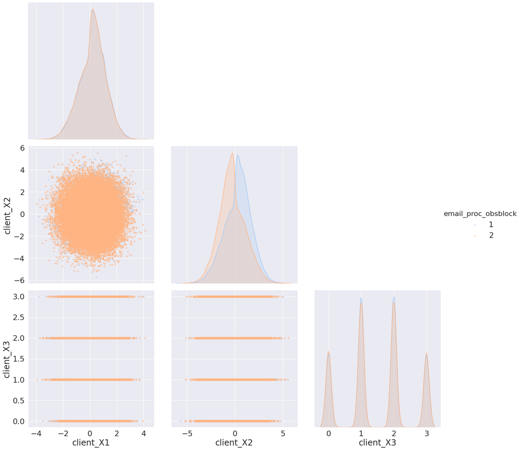

```python
sel_cases_idx = np.where((training_data_melted.email_proc_fast_responder == 0) & (training_data_melted.email_proc_obsblock > 0))[0]
sel_cases_idx = training_data_melted.index[sel_cases_idx]
data_viz = training_data_melted.iloc[sel_cases_idx,:].copy()
data_viz.reset_index(drop = True, inplace = True)
data_viz.head()

data_viz = data_viz.filter(['email_proc_obsblock','client_X1','client_X2','client_X3'])
g = sns.pairplot(data_viz,  hue="email_proc_obsblock", palette="pastel",  height = 6, corner=True, markers="+")
```

- in this chart, it is clear that X2 has a obvious predictive power to distinguish between customers that prefer to read e-mails at evening vs. customers that prefer to read them in the mornings

let's try to understand how much is this power by analyzing boxplots of our target variable by the quantiles of client_X2 variable...

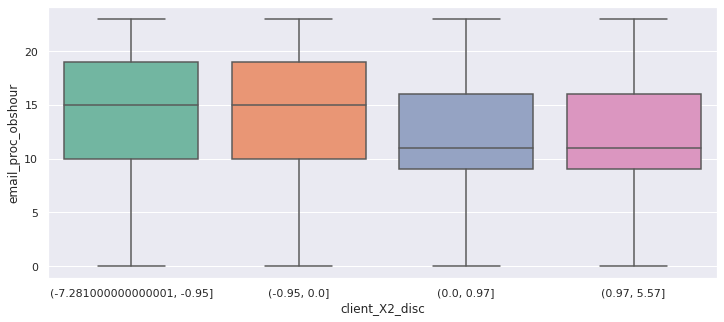

```python
training_data_melted['client_X2_disc']  = pd.qcut(training_data_melted['client_X2'], q=4)
plt.figure(figsize=(12,5))
sns.set(font_scale=1)
g = sns.boxplot(data = training_data_melted,  palette="Set2",   x = 'client_X2_disc', y = 'email_proc_obshour')
```

- In this plot, X2 seem to be quite unrelated with our target in a continuous fashion
- however, there is a clearly mean shift for positive values of this variable

Let's try to see how the target densities shift based on this cutoff point of client_X2...

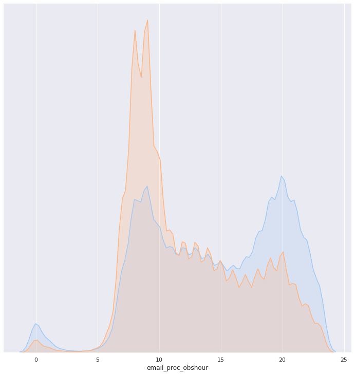

```python
training_data_melted['client_X2_pos']  = pd.qcut(training_data_melted['client_X2'], q=2)
data_viz = training_data_melted.filter(['email_proc_obshour','client_X2_pos'])
g = sns.pairplot(data_viz,  hue="client_X2_pos", palette="pastel",  height = 10, corner=True, markers="+")
g._legend.remove()
```

- for positive values of client X2, the users typically read the e-mails only in the morning
- for negative values of client_X2, the users either read the e-mails in the morning or in late afternoon

Let's now understand how the observed times distribution is affected by the removal of the "immediate readers" as well.

To do that, we create a new feature w/ 4 levels that basically maps all possible cases between fast_readers yes/no and client_X2_positive_value yes/no.

We use that feature to colour the different densities.

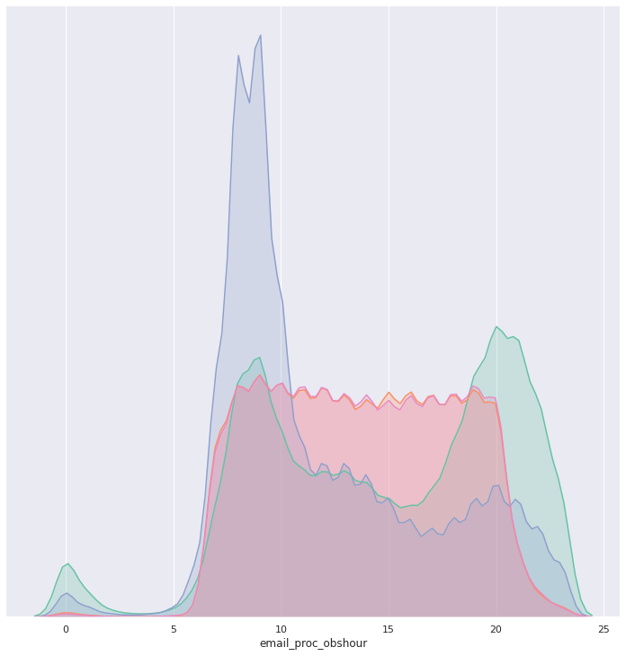

```python
training_data_melted["client_X2_pos"] = training_data_melted["client_X2_pos"].astype('category')
training_data_melted["client_X2_pos"] = pd.Categorical(training_data_melted["client_X2_pos"]).rename_categories(['0','1'])
training_data_melted['new_category'] = np.array(list(map(int, training_data_melted["client_X2_pos"].to_numpy()))) * 2 + training_data_melted["email_proc_fast_responder"].to_numpy()

data_viz = training_data_melted.filter(['email_proc_obshour','new_category'])
g = sns.pairplot(data_viz,  hue='new_category', palette="Set2",  height = 10, corner=True, markers="+")
g._legend.remove()
```

The distribution is indeed different for fast readers (regardless of the value of X2)...being uniform between 07h-20h.

Now, Let's use Parallel coordinate Plots (PCP) to explore the predictive power of these variables over the original dataset

Let's restrict the analysis to the continuous features, X1 and X2...and let's use the hour of the day as target, ordering the colors by the observed hour...

If X1 and X2 have capacity to predict the observed time of the day and hour-level, that would be clear by the colors of the PCP...

```python
data_viz = training_data_melted.filter(['client_X1','client_X2','email_proc_obshour'])

#filtering cases only to be during the day
sel_cases_idx = np.where((data_viz.email_proc_obshour >= 7) & (training_data_melted.email_proc_obshour <=23))[0]
sel_cases_idx = data_viz.index[sel_cases_idx]
data_viz = data_viz.iloc[sel_cases_idx,:].copy()
data_viz.reset_index(drop = True, inplace = True)
data_viz.head()
```

|  | client_X1 | client_X2 | email_proc_obshour |
| --- | --- | --- | --- |
| 0 | -2.1 | 0.09 | 15 |
| 1 | -2.1 | 0.09 | 10 |
| 2 | -2.1 | 0.09 | 12 |
| 3 | -2.1 | 0.09 | 11 |
| 4 | -2.1 | 0.09 | 21 |

```python
#use only a small part of the dataset
data_viz_sample = data_viz.sample(frac=0.05, random_state=seed_constant).copy()
data_viz_sample_feats = data_viz_sample.drop(columns = 'email_proc_obshour').copy()
data_viz_sample_feats.head()
```

|  | client_X1 | client_X2 |
| --- | --- | --- |
| 97417 | 0.59 | 0.34 |
| 450927 | 0.79 | -0.93 |
| 109877 | -1.05 | 1.38 |
| 72740 | 0.68 | 1.92 |
| 299138 | -0.10 | -2.51 |

```python
#scaling features - necessary for plotting parallel lines

scaler = StandardScaler()
scaler.fit(data_viz_sample_feats)
scaled_features = StandardScaler().fit_transform(data_viz_sample_feats.values)
data_viz_sample_feats = pd.DataFrame(scaled_features,index=data_viz_sample_feats.index,columns=data_viz_sample_feats.columns)

#adding label back
data_viz_sample_feats['email_proc_obshour'] = data_viz_sample['email_proc_obshour']
data_viz_sample_feats = data_viz_sample_feats.sort_values('email_proc_obshour').copy()
data_viz_sample_feats.head()
```

|  | client_X1 | client_X2 | email_proc_obshour |
| --- | --- | --- | --- |
| 91651 | 1.293613 | 0.586453 | 7 |
| 469890 | -0.679798 | 0.869065 | 7 |
| 98018 | -0.539556 | 0.077753 | 7 |
| 521217 | -0.319175 | -0.268446 | 7 |
| 440115 | 0.522280 | 0.325038 | 7 |

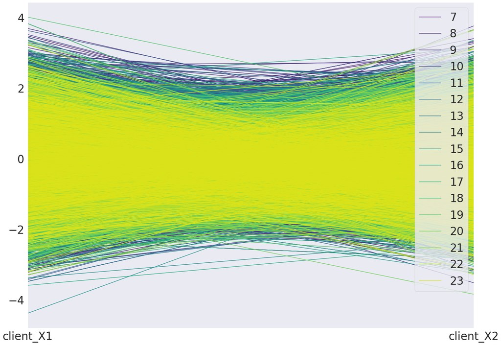

```python
#generating color pallete for chart
palette = sns.color_palette(palette = "viridis", n_colors = len(data_viz_sample_feats.email_proc_obshour.unique()))

#plotting parallel lines
plt.figure(figsize=(24,18))
sns.set(font_scale=3)
pd.plotting.parallel_coordinates(data_viz_sample_feats, 'email_proc_obshour', color=palette)#, sort_labels = True)
```

- There is some predictive power in the X1, X2 features...however, it is clear that they are not descriminitive enough to predict on <60m granularity...

### 1.4 Training/Test Set Preparation

Now that we've completed EDA, let's prepare both the training set and the test set for the modelling stage

```python
#columns to keep
training_data_melted = training_data_melted.filter(['clientID', 'client_X1', 'client_X2', 'client_X3', 'email_proc_obstime', 'email_proc_obshour', 'email_proc_restime', 'email_proc_obsblock', 'email_proc_fast_responder','email_M'])

#apply processing to the test_set as well

#melting
feats_to_melt = grep(test_data.columns, "email_TS", i=False, v=False)
test_data_melted_ts = pd.melt(test_data, id_vars = 'clientID', value_vars = feats_to_melt)

feats_to_melt = grep(test_data.columns, "email_TO", i=False, v=False)
test_data_melted_to = pd.melt(test_data, id_vars = 'clientID', value_vars = feats_to_melt)

feats_to_keep = grep(test_data.columns, "email_T", i=False, v=True)
test_data_melted = test_data_melted_ts.merge(test_data.filter(feats_to_keep), how="left", left_on="clientID", right_on = 'clientID').copy().reset_index()
test_data_melted = test_data_melted.merge(test_data_melted_to, on="clientID").copy().reset_index()
test_data_melted.drop(columns = ['level_0','index'], inplace = True)

#filtering only relevant lines
sel_cases_idx = np.where(test_data_melted.variable_x.str.slice(start = 8, stop = 10) == test_data_melted.variable_y.str.slice(start = 8, stop = 10))[0]
sel_cases_idx = test_data_melted.index[sel_cases_idx]

test_data_melted = test_data_melted.iloc[sel_cases_idx,:].copy()
test_data_melted.reset_index(drop = True, inplace = True)

sel_cases_idx = np.where(np.logical_not(test_data_melted.isnull().any(axis=1)))[0]
sel_cases_idx = test_data_melted.index[sel_cases_idx]

test_data_melted = test_data_melted.iloc[sel_cases_idx,:].copy()
test_data_melted.reset_index(drop = True, inplace = True)


#sanity check
test_data_melted.head(50)
test_data_melted.shape
```

```
(239395, 9)
```

```python
#construct features

#minutes sent
hours = test_data_melted.value_x.str.slice(start = 0, stop = 2).to_numpy()
minutes = test_data_melted.value_x.str.slice(start = 3, stop = 5).to_numpy()
test_data_melted['email_senttime'] = hours.astype(int) * 60 + minutes.astype(int)

#minutes observed
hours = test_data_melted.value_y.str.slice(start = 0, stop = 2).to_numpy()
minutes = test_data_melted.value_y.str.slice(start = 3, stop = 5).to_numpy()
test_data_melted['email_proc_obstime'] = hours.astype(int) * 60 + minutes.astype(int)

#hours observed
test_data_melted['email_proc_obshour'] = hours.astype(int)

#response_time
test_data_melted['email_proc_restime'] = test_data_melted['email_proc_obstime'] - test_data_melted['email_senttime']
sel_cases_idx = np.where(test_data_melted['email_proc_restime'] < 0)[0]
sel_cases_idx = test_data_melted.index[sel_cases_idx]
test_data_melted.loc[sel_cases_idx,'email_proc_restime'] = test_data_melted.loc[sel_cases_idx,'email_proc_restime'] + (24*60)


#dropping original melted columns
test_data_melted = test_data_melted.drop(columns = ['variable_x','value_x', 'variable_y', 'value_y'])

#discretization of the target
test_data_melted['email_proc_obsblock'] = 0

sel_idx = np.where((test_data_melted['email_proc_obshour'] >= 7) & (test_data_melted['email_proc_obshour'] < 13))[0]
sel_idx = test_data_melted.index[sel_idx]
test_data_melted.loc[sel_idx,'email_proc_obsblock'] = 1
print(len(sel_idx))

sel_idx = np.where((test_data_melted['email_proc_obshour'] >= 13) & (test_data_melted['email_proc_obshour'] < 24))[0]
sel_idx = test_data_melted.index[sel_idx]
test_data_melted.loc[sel_idx,'email_proc_obsblock'] = 2
print(len(sel_idx))
```

```
110678
122129
```

```python
#adding up the fast email flag
data_viz = test_data_melted.filter(['clientID','email_proc_restime','email_proc_obstime', 'email_proc_obsblock'])


#create number of favorable cases vs. number of observations
data_viz2 = data_viz.copy()
sel_cases_idx = np.where(data_viz2.email_proc_restime < min_th_fast_response)[0]
sel_cases_idx = data_viz2.index[sel_cases_idx]
data_viz2 = data_viz2.iloc[sel_cases_idx,:].copy()
data_viz2.reset_index(drop = True,  inplace = True)

fast_counts = data_viz2.groupby(['clientID']).size().to_frame()
fast_counts.reset_index(level=0, inplace=True)
fast_counts = fast_counts.rename(columns={0: "fast_counts"})

all_counts = data_viz.groupby(['clientID']).size().to_frame()
all_counts.reset_index(level=0, inplace=True)
all_counts = all_counts.rename(columns={0: "all_counts"})

fast_counts = fast_counts.merge(all_counts, how="left", left_on="clientID", right_on = 'clientID').copy().reset_index(drop = True)
fast_counts['perc_fast_counts'] = fast_counts.fast_counts / fast_counts.all_counts

#selecting cases with 4+ e-mails sent/received and with 50%+ of fast responses
sel_fast_cases_idx = np.where((fast_counts.perc_fast_counts >= 0.5) & (fast_counts.all_counts >= 4))[0]
fast_counts = fast_counts.iloc[sel_fast_cases_idx,:].copy()
fast_counts.reset_index(drop = True, inplace = True)


#merge to prune out invalid clientIDs with sanity check
print(fast_counts.shape)
fast_counts = fast_counts.merge(data_viz2, how="left", left_on="clientID", right_on = 'clientID').copy().reset_index(drop = True)
print(len(fast_counts.clientID.unique()))
#done
```

```
(5769, 4)
5769
```

```python
#removing all non-fast cases w/ sanity check
print(len(fast_counts.clientID.unique()))
sel_cases_idx = np.where(fast_counts.email_proc_restime < min_th_fast_response)[0]
sel_cases_idx = fast_counts.index[sel_cases_idx]
fast_counts = fast_counts.iloc[sel_cases_idx,:].copy()
fast_counts.reset_index(drop = True,  inplace = True)
print(len(fast_counts.clientID.unique()))
```

```
5769
5769
```

```python
#counting occurrences in different periods of the day
df = fast_counts.groupby('clientID')['email_proc_obsblock'].value_counts().unstack()
df = df.count(axis=1).to_frame()
df.reset_index(level=0, inplace=True)
df = df.rename(columns={0: "different_periods"})

#excluding cases which occur always in the same period of the day w/sanity check
print(df.shape)
sel_cases_idx = np.where(df.different_periods > 1)[0]
sel_cases_idx = df.index[sel_cases_idx]
df = df.iloc[sel_cases_idx,:].copy()
df.reset_index(drop = True,  inplace = True)
print(df.shape)
```

```
(5769, 2)
(5362, 2)
```

```python
#adding info to original test set, w/ sanity check
print(df.shape)
test_data_melted['email_proc_fast_responder'] = 0
sel_cases_idx = np.where(test_data_melted.clientID.isin(df.clientID))[0]
sel_cases_idx = test_data_melted.index[sel_cases_idx]
test_data_melted.loc[sel_cases_idx,'email_proc_fast_responder'] = 1
print(len(test_data_melted.clientID[sel_cases_idx].unique()))

test_data_melted = test_data_melted.filter(['clientID', 'client_X1', 'client_X2', 'client_X3', 'email_proc_obstime', 'email_proc_obshour', 'email_proc_restime', 'email_proc_obsblock', 'email_proc_fast_responder','email_M'])
```

```
(5362, 2)
5362
```

Let's now briefly compare the distributions of training and test set to guarantee that nothing went terribly wrong...

```
Training set distributions:
```

```
array([[<matplotlib.axes._subplots.AxesSubplot object at 0x7f02d47f2d30>,
      dtype=object)
```

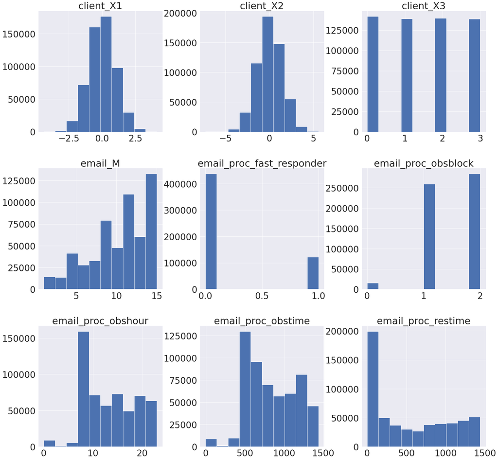

```python
#
#compare distributions of new features between train and test
#
print("Training set distributions:")
training_data_melted.drop(columns='clientID').hist(figsize=(30, 30))
```

```
Test set distributions:
```

```
array([[<matplotlib.axes._subplots.AxesSubplot object at 0x7f02cdc50cf8>,
      dtype=object)
```

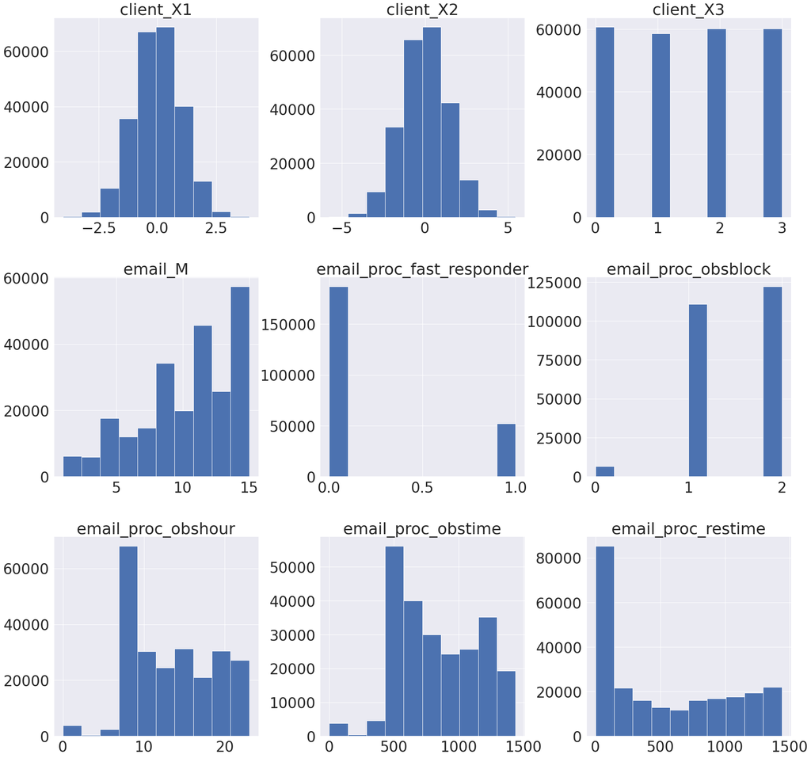

```python
print("Test set distributions:")
test_data_melted.drop(columns='clientID').hist(figsize=(30, 30))
```

- The distributions seem similar, as expected.

Let's just store these datasets for further usage...if needed...

```python
#storing resulting objects
training_data_melted.to_csv(path + "proc.data/training_data.csv", index=False)
test_data_melted.to_csv(path + "proc.data/test_data.csv", index=False)
```

## II) Modelling - Objectives and Tasks

- Design a Baseline Model and a Evaluation Protocol
- Engineer Features that can help modelling
- Design the most adequate learning configuration for the problem defined
- Derive possible directions for future work

```python
#preparing objects for modelling...
training_data = pd.read_csv(path + "proc.data/training_data.csv")
test_data = pd.read_csv(path + "proc.data/test_data.csv")
```

## 2.1 Evaluation

We start this part by defining an evaluation criteria to our predictions

The idea is to minimize the difference between sent-emails and observed e-mails. To do that, we compute the residuals to all possible observation times existing on the test-set and we select the minimum time.The residuals are corrected for the next day issue by adding 24h to the negative ones.

Besides the desired metric to minimize (mae), the function also reports rmse and the percentages of cases, that are read within 1h, 2h or in more than 8h.

```python
def evaluation(preds, obs, data, verbose = True):

    #give 15 minutes slack on predictions
    preds = preds - (15)
    residuals = obs - preds

    #correction of negative residuals to next day
    sel_idx = np.where(residuals < 0)[0]
    residuals[sel_idx] = residuals[sel_idx] + 24*60

    #select the closer observation time of each customer
    data = data.filter(['clientID']).copy()
    data['residuals'] = residuals
    residuals_df = data.groupby(['clientID']).min()
    residuals = residuals_df.residuals.to_numpy()

    #computing evaluation metrics
    rmse = math.sqrt(np.mean(residuals * residuals))
    mae = np.mean(residuals)
    perc_60 = len(np.where(residuals < 60)[0]) / len(residuals) * 100
    perc_120 = len(np.where(residuals < 120)[0]) / len(residuals) * 100
    perc_480 = len(np.where(residuals > 480)[0]) / len(residuals) * 100

    if (verbose):
        print(f"RMSE: {rmse:.2f}, MAE:{mae:.2f}, <1h:{perc_60:.2f}%, <2h:{perc_120:.2f}%, >8h:{perc_480:.2f}%")

    return residuals_df
```

### 2.2 Model 0 - Baseline

We start modelling by creating a naive baseline.

The baseline simply generates random sending times from gaussian distributions which parameters come from the univariate empirical means/sd (observed) of the target

```python
#baseline generation function
def baseline_generator(N, prob, mu_m, mu_e, sigma_m, sigma_e):

    #randomly deciding morning and afternoon peaks
    s = np.random.binomial(1, prob, N)

    # -1 for mornings, -2 for evening
    s = s-2

    #sampling times for morning peak
    n = len(np.where(s==-1)[0])
    np.random.seed(seed_constant)
    mp = np.random.normal(mu_m, sigma_m , n)

    #truncating values to 0 to 24*60
    sel_idx = np.where(mp<0)[0]
    if (len(sel_idx) > 0):
        mp[sel_idx] = 0

    sel_idx = np.where(mp>=24*60)[0]
    if (len(sel_idx) > 0):
        mp[sel_idx] = 0

    #sampling times for evening peak
    n = len(np.where(s==-2)[0])
    np.random.seed(seed_constant)
    ep = np.random.normal(mu_e, sigma_e, n)

    #truncating values to 0 to 24*60
    sel_idx = np.where(ep<0)[0]
    if (len(sel_idx) > 0):
        ep[sel_idx] = 0

    sel_idx = np.where(ep>=24*60)[0]
    if (len(sel_idx) > 0):
        ep[sel_idx] = 0

    #constructing final response
    sel_idx = np.where(s==-1)[0]
    s[sel_idx] = mp

    sel_idx = np.where(s==-2)[0]
    s[sel_idx] = ep

    return s
```

Processing baseline predictions...

```python
morning_peak = len(np.where(training_data.email_proc_obsblock == 1)[0])
afternoon_peak = len(np.where(training_data.email_proc_obsblock == 2)[0])
prob_morning = morning_peak / (morning_peak+afternoon_peak)

#getting baseline predictions
preds = baseline_generator(N = len(test_data), prob = prob_morning, mu_m = 9*60, sigma_m = 2*60, mu_e = 20*60, sigma_e = 3*60)
obs = test_data.email_proc_obstime

#showing evaluation of baseline
print("Baseline:")
_ = evaluation(preds, obs, test_data)
```

```
Baseline:
RMSE: 332.93, MAE:200.89, <1h:35.68%, <2h:56.83%, >8h:13.06%
```

These are the results we need to beat!

Let's start by identifying fast responders as they seem pretty easy to model. From the EDA section, we take a dependency on X1 and X3 (be 0/3).

Let's try to model that relationship linearly.

```python
training_model0 = training_data.filter(['clientID','client_X1','client_X3','email_proc_fast_responder']).drop_duplicates().copy()
```

Following observed pattern during EDA, we binarize client_X3 for this task...

```python
#preparing client_X3 binarized for this task on the training set
training_model0['client_X3_proc'] = 0
sel_idx = np.where((training_model0.client_X3 == 3) | (training_model0.client_X3 == 0))[0]
sel_idx = training_model0.index[sel_idx]
training_model0.loc[sel_idx,'client_X3_proc'] = 1
training_model0 = training_model0.filter(['client_X1','client_X3_proc','email_proc_fast_responder'])
training_model0.head()
```

|  | client_X1 | client_X3_proc | email_proc_fast_responder |
| --- | --- | --- | --- |
| 0 | -2.10 | 1 | 1 |
| 14 | 1.50 | 1 | 0 |
| 17 | 0.62 | 1 | 0 |
| 21 | -0.18 | 0 | 0 |
| 27 | -0.09 | 1 | 1 |

```python
#prepare test_set similarly
test_model0 = test_data.filter(['clientID','client_X1','client_X3','email_proc_fast_responder']).drop_duplicates().copy()

test_model0['client_X3_proc'] = 0
sel_idx = np.where((test_model0.client_X3 == 3) | (test_model0.client_X3 == 0))[0]
sel_idx = test_model0.index[sel_idx]
test_model0.loc[sel_idx,'client_X3_proc'] = 1
test_model0 = test_model0.filter(['client_X1','client_X3_proc','email_proc_fast_responder'])
test_model0.head()
```

|  | client_X1 | client_X3_proc | email_proc_fast_responder |
| --- | --- | --- | --- |
| 0 | -0.33 | 0 | 0 |
| 1 | -1.35 | 1 | 1 |
| 16 | -0.62 | 1 | 1 |
| 21 | -0.31 | 0 | 0 |
| 34 | 0.58 | 0 | 0 |

Modelling the probability of being a fast responder using logistic regression...

```python
RLR = LogisticRegression(penalty = 'none',
                         solver = 'saga',
                         random_state = seed_constant)

RLR.fit(training_model0.filter(['client_X1','client_X3_proc']),training_model0.email_proc_fast_responder)
```

```
LogisticRegression(C=1.0, class_weight=None, dual=False, fit_intercept=True,
                   intercept_scaling=1, l1_ratio=None, max_iter=100,
                   multi_class='auto', n_jobs=None, penalty='none',
                   random_state=33, solver='saga', tol=0.0001, verbose=0,
                   warm_start=False)
```

Let's briefly inspecting resulting model...

```python
dValues = RLR.coef_[0]
print('brief model view:')
print(len(dValues))
print(dValues)
```

```
brief model view:
2
[-1.86558141  6.98345914]
```

Let's evaluate the model over our training set and test set...

```python
#evaluating in the training set
outputs = RLR.predict(training_model0.filter(['client_X1','client_X3_proc']))
preds = RLR.predict_proba(training_model0.filter(['client_X1','client_X3_proc']))
preds_flat = pd.DataFrame(preds)[[1]]
roc_train = roc_auc_score(training_model0.email_proc_fast_responder, preds_flat)
print("Train AUC:")
print(roc_train)
```

```
Train AUC:
0.9488505715789552
```

```python
acc = len(np.where(outputs == training_model0.email_proc_fast_responder)[0]) / len(outputs)
print("Train Accuracy:")
print(acc)
```

```
Train Accuracy:
0.8821428571428571
```

```python
#evaluating in the test set
outputs = RLR.predict(test_model0.filter(['client_X1','client_X3_proc']))
preds = RLR.predict_proba(test_model0.filter(['client_X1','client_X3_proc']))
preds_flat = pd.DataFrame(preds)[[1]]
roc_test = roc_auc_score(test_model0.email_proc_fast_responder, preds_flat)
print("Test AUC:")
print(roc_test)
```

```
Test AUC:
0.9498246962151453
```

```python
acc = len(np.where(outputs == test_model0.email_proc_fast_responder)[0]) / len(outputs)
print("Test Accuracy:")
print(acc)
```

```
Test Accuracy:
0.8812666666666666
```

- The model is not only strong but it generalizes well on unseen data.

Let's store its outputs in the original dataset for further usage.The idea is to use this as a maeta-feature to other models that may not be able to capture the linear effects of this relationship so well...

```python
#adding processed feature X3 to original datasets

training_data['client_X3_proc'] = 0
sel_idx = np.where((training_data.client_X3 == 3) | (training_data.client_X3 == 0))[0]
sel_idx = training_data.index[sel_idx]
training_data.loc[sel_idx,'client_X3_proc'] = 1

test_data['client_X3_proc'] = 0
sel_idx = np.where((test_data.client_X3 == 3) | (test_data.client_X3 == 0))[0]
sel_idx = test_data.index[sel_idx]
test_data.loc[sel_idx,'client_X3_proc'] = 1

#adding predicted class and probabilities (meta-features) to original dataset
training_data['pe_email_proc_fast_responder'] = RLR.predict(training_data.filter(['client_X1','client_X3_proc']))
preds = RLR.predict_proba(training_data.filter(['client_X1','client_X3_proc']))
preds_flat = pd.DataFrame(preds)[[1]]
training_data['pp_email_proc_fast_responder'] = preds_flat

test_data['pe_email_proc_fast_responder'] = RLR.predict(test_data.filter(['client_X1','client_X3_proc']))
preds = RLR.predict_proba(test_data.filter(['client_X1','client_X3_proc']))
preds_flat = pd.DataFrame(preds)[[1]]
test_data['pp_email_proc_fast_responder'] = preds_flat
```

### 2.3) Model 1 - Vanilla Regression with RF

Here, we will try simply to model the problem as a regression one.

One row per sent/obs. email, using all vanilla client features + prob. meta-feature.

Please note that we tune RF to randomly select a splitting feature in each node and we reduce the size of bootstraps to 10% of total training sample size. This aims to increase the heterogeneousity of each tree as we only have 4 features but 100s of rows.

```python
#learning model
max_samples_boots = int(0.1 * len(training_data))
model1 = RandomForestRegressor(n_estimators = 100, random_state = seed_constant, min_samples_split = 100, max_features = 1, max_samples = max_samples_boots)
_ = model1.fit(training_data.filter(['client_X1','client_X2','client_X3', 'pp_email_proc_fast_responder']), training_data.email_proc_obstime)

#getting predictions
preds = model1.predict(test_data.filter(['client_X1','client_X2','client_X3', 'pp_email_proc_fast_responder']))
obs = test_data.email_proc_obstime

#evaluating model in the test set
print("Model 1, Vanilla RF for regression:")
_ = evaluation(preds, obs, test_data)
```

```
Model 1, Vanilla RF for regression:
RMSE: 382.04, MAE:235.52, <1h:28.73%, <2h:45.53%, >8h:9.51%
```

- **This solution is even worst than the baseline!!**
- There are two problems:
  - 1) the loss function is symmetric (ours is not)
  - 2) On the top of that, the aggregation function in the leaves is the average...which severely contributes to a bias against larger observed times (afternoon)...aggravating further the abovementioned loss problem.

### 2.4) Model 2 - Binary Classification w/RF (removing nighttime examples)

The idea with this model is to simply decide per customer if we should send e-mails in the morning or in the afternoon. Additionally, we omit evening examples as they are very few anyway and do not seem to follow any pattern.

```python
#remove time block 0 examples from training
training_data_m2 = training_data.copy()
sel_idx = np.where(training_data.email_proc_obsblock > 0)[0]
sel_idx = training_data_m2.index[sel_idx]
training_data_m2 = training_data_m2.iloc[sel_idx,:].copy()
training_data_m2.reset_index(drop = True,  inplace = True)

#learning classification model
max_samples_boots = int(0.1 * len(training_data_m2))
model2 = RandomForestClassifier(n_estimators = 100, random_state = seed_constant, min_samples_split = 100, max_features = 1, max_samples = max_samples_boots, oob_score = True)
_ = model2.fit(training_data_m2.filter(['client_X1','client_X2','client_X3','pp_email_proc_fast_responder']), training_data_m2.email_proc_obsblock)

#inspecting OOB accuracy to check how good the model discriminates both classes
print("OOB Accuracy")
print(model2.oob_score_)
```

```
OOB Accuracy
0.6287751770389817
```

- The OOB score shows that the descrimination power of this model is actually low...

Let's prepare prediction from classification labels. We use a conservative approach to the estimation of the predictions by taking two fixed times to send emails: the beginning of the intervals.

```python
preds = model2.predict(test_data.filter(['client_X1','client_X2','client_X3','pp_email_proc_fast_responder']))
preds[np.where(preds == 2)] = 13*60+15
preds[np.where(preds == 1)] = 7*60+15

obs = test_data.email_proc_obstime

print("Model 2, Vanilla RF for bin. classification:")
_ = evaluation(preds, obs, test_data)
```

```
Model 2, Vanilla RF for bin. classification:
RMSE: 281.88, MAE:163.86, <1h:36.85%, <2h:63.09%, >8h:6.44%
```

- This model is already slightly better than our baseline...uff, **we did it!**

However, we are still working with a symmetric loss. Mmoreover, the affected intervals are very lengthy...how can address that to improve our performance?

### 2.5) Model 3 - Cost-Sensitive lightGBM w/ custom loss function for Regression

The tradeoff between the non-linearities of the target function that we are trying to approximate vs. the optimization procedures, loss functions and ensemble aggregations that come on off-the-shelf learners (like the ones we are using here) is challenging.

One of the main modelling problems are the "next day" predictions...and the associated assymetric errors.

If the algorithm "risks" on converging to send an e-mail late in the day, #the chance that it will get read next day increases massively - as the e-mails read during nighttime are neglectible. That turns that the loss of missing the customer's reading time is not -1h but +10h instead (if not more).

This problem has an assimetric nature and to model it more adequate we will need an assymetric loss.

We will do it with lightGBM package, which supports user-defined losses as long as the hessian and the gradient are defined (mandatory for gbm-like algorithms).The main reason to prefer to try regression vs. classification w/custom-loss is on the metric that is desired to optimize: the difference between sent e-mail time and obs. e-mail time.

Let's start by processing the data for model training...

```python
#processing data
training_data_m4 = training_data.copy()
test_data_m4 = test_data.copy()

#remove evening examples from training
#filtering out cases only during the night
sel_idx = np.where((training_data_m4.email_proc_obshour >= 7) & (training_data_m4.email_proc_obshour < 24))[0]
sel_idx = training_data_m4.index[sel_idx]
training_data_m4 = training_data_m4.iloc[sel_idx,:].copy()
training_data_m4.reset_index(drop = True, inplace = True)

#preparing to learn model
training_model4 = training_data_m4.filter(['client_X2', 'pp_email_proc_fast_responder'])
training_label4 = training_data_m4.email_proc_obstime

test_model4 = test_data_m4.filter(['client_X2', 'pp_email_proc_fast_responder'])
test_label4 = test_data_m4.email_proc_obstime
```

**Custom assymetric loss**

- It is difficult to add a constant to the residuals due to the fact that we need both the gradient and the hessian to use GBM.
- Instead, we will use a linear penalty factor of 100 to force clearly the algorithm to correct the error on these examples...

```python
def custom_asymmetric_train(y_true, y_pred):
    residual = (y_true - y_pred).astype("float")

    #assymetric penalty for negative errors that pass for next day
    penalty = 100

    #rough calculation of gradient and hessian
    grad = np.where(residual<0, -2*penalty*residual, -2*residual)
    hess = np.where(residual<0, 2*penalty, 2.0)
    return grad, hess
```

Here we learn the model with very standard hyperparameters + our custom loss. The exception is the subsampling at each tree growing of 10% of the total training sample, which is similar to what we already did with RF for the very same reasons.

```python
model4 = lightgbm.LGBMRegressor()

model4.set_params(**{'objective': custom_asymmetric_train},
                  learning_rate=0.3,
                  n_estimators = 10,
                  subsample = 0.1,
                  random_state = seed_constant)


model4.fit( X = training_model4, y = training_label4)
```

```
LGBMRegressor(boosting_type='gbdt', class_weight=None, colsample_bytree=1.0,
              importance_type='split', learning_rate=0.3, max_depth=-1,
              min_child_samples=20, min_child_weight=0.001, min_split_gain=0.0,
              n_estimators=10, n_jobs=-1, num_leaves=31,
              objective=<function custom_asymmetric_train at 0x7f02c781a378>,
              random_state=33, reg_alpha=0.0, reg_lambda=0.0, silent=True,
              subsample=0.1, subsample_for_bin=200000, subsample_freq=0)
```

```python
#getting predictions
preds = model4.predict(test_model4)
obs = test_label4

#evaluating the model
print("Model 3, lightgbm with assymetric custom loss for regression:")
residuals = evaluation(preds, obs, test_data_m4)
```

```
Model 3, lightgbm with assymetric custom loss for regression:
RMSE: 226.01, MAE:123.58, <1h:51.95%, <2h:72.79%, >8h:6.16%
```

- **This model is a considerable improvement to anything above!**
- In average, a customer takes ~2h to open the sent e-mails based on our model.
- 52% of the e-mails are read in 1h and 73% are read within 2h. Only 6% take more than 8h to read.

### 2.6) Future Directions

How can we further improve our last model?

Let's look to the distribution of our predictions...

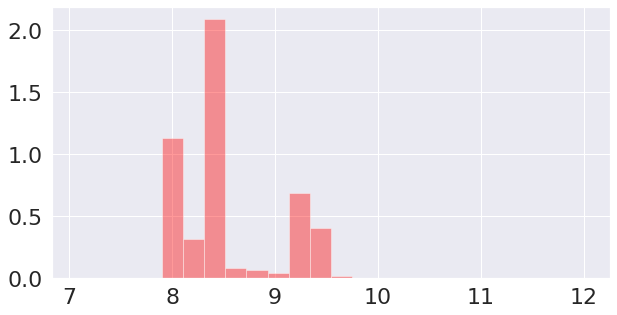

```python
plt.figure(figsize=(10,5))
sns.set(font_scale=2)
sns.distplot(preds/60, kde=False, color='red', bins = 24, norm_hist = True)
```

- As you can see, this distribution is very far from the original target one we saw during EDA. **Does this makes sense?**

Well, the short answer is: Yes, it does :)

If we look again carefully to the different densities observed in EDA vs. different values of these two variables, we see that the users either read the e-mail at morning peak at evening peak or both. A conservative approach to minimize large errors (the next day issue) would be to always send e-mails during the morning peak and optimize the sending times in that period...as users always tend to always have at least one observed time there.

Consequently, the cost-sensitive nature of this learner forces it to not take chances on predicting even on sending e-mails after 10h, concentrating all the sendings between 8h-10h.

From EDA, and among the available features, it seems not to exist much more predict power to do significantly better than this.

Naturally, one way to improve is to be able to safelly send e-mails later in the day,

Enlarging the prediction outputs. This learner also goes after conditional means...which, in turn, are much more frequent in the morning. This, together with the defined loss, results in the present outcome.